# Cardiovascular Disease: An empirical and predictive approach.

Diego Alzate, Jossie Molina Perdomo, Diego Ruiz Saldoval

20/5/2022

## Introduction

Non-communicable diseases comprising cardiovascular diseases, cancer and diabetes are the leading causes of death globally and are also rapidly increasing. According to the National Health Observatory (2013) non-communicable diseases caused approximately 63% of deaths and it is expected that given their level of growth they could reach 73% mortality in Colombia. Within these non-communicable diseases, cardiovascular diseases are the main cause of death, in that order of ideas at a global level 42% of deaths from cardiovascular diseases were due to ischemic heart disease, 34% of deaths were due to cerebrovascular disease, 7% due to arterial hypertension and 2% due to rheumatic heart disease.

Mortality rates for cardiovascular diseases in 1998 to 2011 in Colombia have represented according to the National Health Observatory (2013) 12,475,251 potential years of life lost which implies a rate of 22.5 potential years of life lost per 1000 inhabitants. Based on this scenario, the present work refers to the study of deaths associated with cardiac arrest. For the analysis of this problem we have a database with 4500 observations. The items included in the database are demographic variables, consumption habits and information on the health of individuals, including sex, age, education, smoking or non-smoking status, number of cigarettes consumed, blood pressure level, number of previous cardiac arrests, whether or not one suffers from arterial hypertension, presence or absence of diabetes, cholesterol level, systolic blood pressure, diastolic blood pressure, body mass index, heart rate and glucose level, among others.

To address this problem, it was decided to use a binary response regression method for the classification and prediction of this disease.

## Objectives

### General Objective

To determine the risk factors with the highest incidence of heart disease and, based on this, to predict for new samples whether or not an individual will suffer an acute myocardial attack.

### Specific Objectives

- Characterize the variables involved in the classification of individuals.
- To formulate a classification model to determine whether or not an individual will suffer a cardiac arrest given his or her health characteristics and habits as defined in the predictor variables.
- Determine the most significant risk factors as predictors of cardiac arrest.

### Activity Schedule

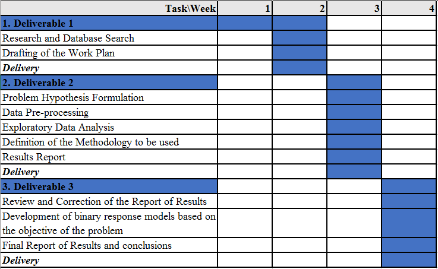

### Problem Context

Given the panorama of coronary artery disease, cancer, which is the second leading cause of death in the United States, occupies a little more than half of the deaths caused by cardiovascular diseases, making these, especially the most common form of cardiovascular disease, coronary artery disease, the leading cause of death in the United States.

According to the Texas Heart Institute, variables have been defined or identified that have the highest probability of a person suffering from cardiovascular disease, these are called risk factors, in that order of ideas these can be divided into primary and secondary. The main risk factors are those for which there is medical evidence that their existence and prevalence generate cardiovascular disease, while the secondary risk factors are those that can increase the probability of contracting this group of diseases.

Given the definition of risk factors, some of these can be controlled while others can be defined as environmental or uncontrollable. The fewer the number of cardiovascular risk factors a person has, the less likely he or she is to suffer from this disease at some point in his or her life. According to the Texas Heart Institute, among the main risk factors, that is, those that are known with certainty to generate this type of disease are:

**High Cholesterol:** Cholesterol is a substance generated by the liver and transported in the blood, it is present in all cells and its function is the formation of cell membranes and some types of hormones in the organism. Cholesterol is also obtained through the consumption of foods of animal origin, i.e. eggs, meat, fish or dairy products.

When there are low density lipoproteins (LDL) in excess, as they circulate through the body by the blood flow they begin to accumulate on the arterial walls, this accumulated plaque hardens and narrows the arteries preventing the flow of oxygen-rich blood, when the coronary arteries suffer this plaque formation there is a greater risk of cardiac arrest.

**Diabetes:** The presence of diabetes can damage the blood vessels and nerves that control the heart generating irregular functioning or total loss of heart function, according to the American Heart Foundation 65% of diabetic patients die from some cardiovascular disease. On the other hand, patients with type II diabetes have a higher cardiovascular risk than patients with type I diabetes.

It has been defined that certain groups of races and/or ethnicities have a higher risk of suffering from diabetes, such as blacks, Hispanics, Polynesians, Asians, Micronesians and Amerindians, so race can become a risk factor for cardiovascular disease.

**Overweight and Obesity:** Overweight and obesity can generate consequences such as increased blood pressure, the presence of diabetes or high blood cholesterol values, therefore these are risk factors for cardiovascular disease.

Obesity is measured from the Body Mass Index (BMI) which implies a ratio between weight and the square of height. This measure correlates moderately with direct measures of body fat. In the case of adults, according to the Center for Disease Control and Prevention, an adult person with a BMI greater than or equal to 30 kg/m2 would be obese and with a BMI of 25 to 29.9 kg/m2 would be overweight.

In that order of ideas this index is not robust for people who are high performance athletes who may have large amounts of muscle mass.

**Smoking:** This habit falls within the controllable risk factors, however, given its capacity to generate addiction associated with the presence of nicotine, it is a challenge to stop its consumption. Cardiovascular health effects include increased heart rate, hardening of the arteries and may cause irregularities in heart rhythm.

**Physical Activity:** Low physical activity increases the risk of cardiovascular disease, since consistent physical activity by itself helps to regulate blood pressure, maintain a healthy weight by burning calories, control the level of cholesterol (LDL) in the blood and diabetes. Moreover, regular physical activity increases the strength of the heart muscle.

**Hereditary conditions:** Heart diseases have the capacity of generational transmission, so if any of the first degree relatives suffered a cardiovascular disease before 55 years of age, there is a higher risk.

Also other major risk factors have intergenerational transmission effects such as arterial hypertension, diabetes and obesity.

**Age:** As age increases, the activity of the heart tends to worsen or deteriorate, the arteries may lose flexibility and gain hardness so that the heart will not be able to pump blood efficiently as it did at younger ages to the muscles of the body; 80% of people who died of a heart attack were older than 65 years of age.

Other major risks for cardiovascular disease are also considered to be chronically or persistently high levels of stress, which is believed to increase heart rate, blood pressure (which can damage the walls of the arteries, so that as they regenerate they can scar, thicken or harden) and the need for oxygen pumped by the heart. On the other hand, alcohol abuse can lead to high blood pressure, irregular heart rhythm and heart muscle disease.

The levels of sex hormones, for example, in the case of women, when they reach menopause, their chances of heart attacks increase considerably.

Once the main risk factors for cardiovascular disease have been defined, there are demographic variables other than age, gender and race that can be predictors of heart attack, thus according to Reiner et al (2011) there is a higher incidence of Sudden Cardiovascular Death in areas that had a low socioeconomic level. Where it was concluded that individuals with lower socioeconomic status possessed a higher burden or amount of cardiovascular disease risk factors associated with lifestyle habits as individual risk factors, poor control on these risk factors and long waits or delays in medical help for acute myocardial infarction. On the other hand, the existence of disparity in hospital variables, mainly the existence of medical equipment and trained personnel, is associated with socioeconomic level and therefore with the survival outcome of individuals who suffer acute myocardial infarction, which implies that economic conditions that are shared in “neighborhoods” or geographic zones have an impact on mortality from acute myocardial infarction.

Given the context of the problem, it would be interesting to address the following hypotheses and answer them based on the methodology of the project:

- The level of high cholesterol has a greater impact than the presence of diabetes on cardiovascular disease associated with acute myocardial infarction.
- The presence of a history of cardiovascular disease is the most significant predictor of 10-year risk of myocardial infarction compared to the other risk factors.
- Daily smoking has less influence than the presence of hypertension on the risk of acute myocardial infarction.
- Female smokers have a lower risk of acute myocardial infarction than male smokers because of the protection against cardiovascular risk provided by estrogen production.
- Elevated heart rate (tachycardia) has a greater effect on the risk of acute myocardial infarction than low heart rate (bradycardia).

### Figure 1: Distribution and correlation of quantitative risk variables for acute myocardial infarction

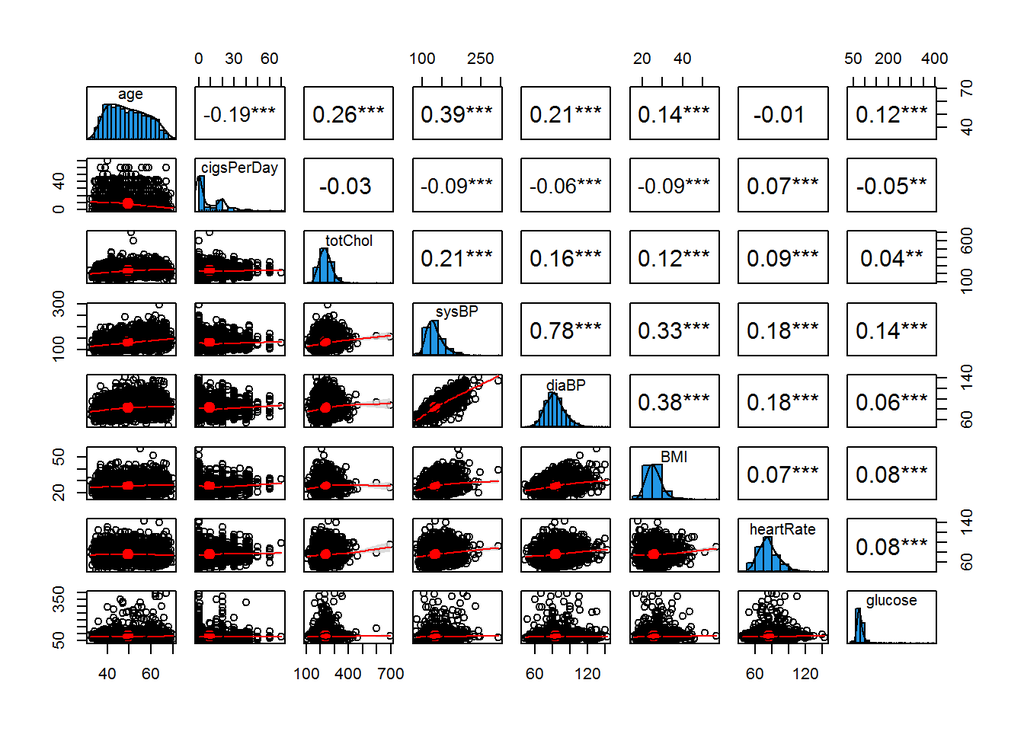

However, it was expected that variables such as Body Mass Index and heart rate among others would correlate, given that a level of overweight or obesity would represent a greater functional burden on the heart.

On the other hand, the highest proportion of people are 49 years old, where 25% of the youngest people are 42 years old or younger, and the youngest person is 32 years old; however, 25% of the oldest people are 56 years old or older.

The cholesterol level within the study group averaged 234 ml/dL, implying that the average person has higher than normal cholesterol levels; people with the highest 25% of cholesterol in the sample have high cholesterol levels, implying the presence of risk factors for cardiovascular health. In terms of Body Mass Index distribution, we have that 50% of the people in the sample are overweight and less than 25% of the individuals suffer from obesity, heart rate which is another relevant factor as a health metric we have that 50% of the individuals have a heart rate between 60 and 100 beats per minute which is a normal range, where the average heart rate is 75. 88 beats per minute and a small percentage that make up the extremes of the distribution present bradycardia or tachycardia, which may be an indicator of heart disease, given that it is possible to use medication to decrease the heart rate; however, it is not possible to state this with certainty when considering that people who perform high and regular levels of physical activity may have heart rate levels lower than 60, now for the case of the right end of the distribution, cardiac arrhythmia is a symptom of possible cardiovascular disease.

### Table 1 and Figure 2: Descriptive Statistics

| Variable | Min | Q1 | Median | Q3 | Max |
| --- | --- | --- | --- | --- | --- |
| Age | 32.00 | 42.00 | 49.00 | 56.00 | 70.0 |
| Number of Cigarettes per Day | 0.00 | 0.00 | 0.00 | 20.00 | 70.0 |
| Diastolic Blood Pressure | 48.00 | 75.00 | 82.00 | 89.88 | 142.5 |
| Body Mass Index | 15.54 | 23.07 | 25.38 | 28.04 | 56.8 |

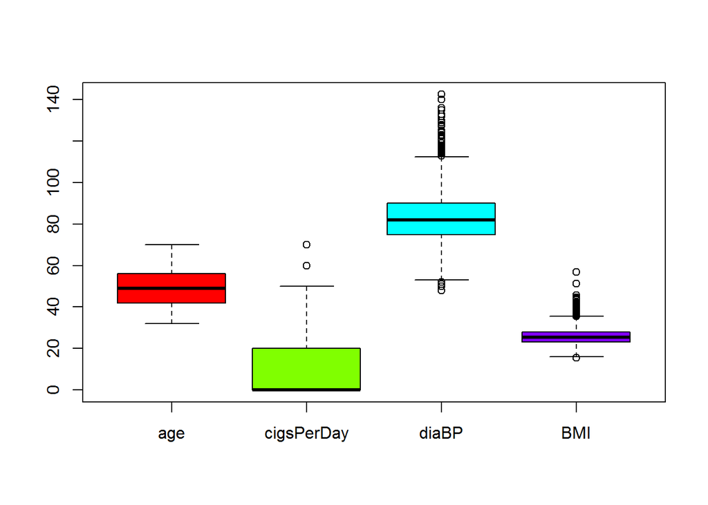

In **Figure 2** we can see that there are individuals where 50% of the people do not use tobacco while 25% of the people who consume this substance smoke 20 cigarettes or more per day, reaching a maximum consumption of 70 cigarettes per day, in that order of ideas 25% of the sample would represent high risk factors in their cardiovascular health.

For diastolic blood pressure, this means the blood pressure measured at the moment when the heart relaxes. We have that according to **Table 1** that 50% of the individuals have a diastolic pressure of 82 millimeters of mercury, which implies that 50% of the people who have higher diastolic pressure may suffer hypertension, however this in case that diastolic pressure is persistent over time and not acute or sporadic at the time of measurement. We can also observe in this measurement that there are several atypical individuals with a diastolic pressure above 115 milliliters of mercury approximately.

### Table 2 and Figure 3: Descriptive Statistics

| Variable | Min | Q1 | Median | Q3 | Max |
| --- | --- | --- | --- | --- | --- |
| Total Cholesterol | 107.0 | 206 | 234 | 263 | 696 |
| Systolic Blood Pressure | 83.5 | 117 | 128 | 144 | 295 |
| Heart Rate | 44.0 | 68 | 75 | 83 | 143 |
| Glucose Level | 40.0 | 71 | 78 | 86 | 394 |

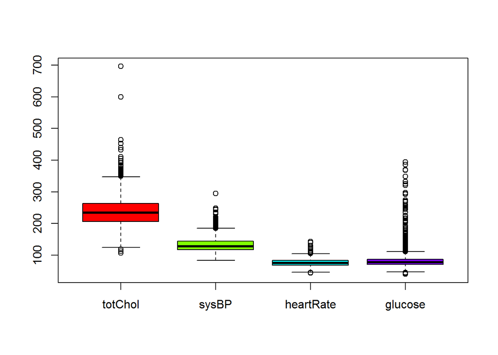

In **Figure 3** we can see that for systolic blood pressure, that is when the heart contracts to send blood to the body, 25% of people have less than 117 millimeters of mercury of systolic pressure, this may imply the presence of low blood pressure either as a pathological consequence or as an effect of some medication they are taking, on the other hand 25% of people with higher systolic blood pressure have levels greater than or equal to 144 millimeters of mercury reaching up to 295 millimeters of mercury. These levels are abnormal and may imply the presence of high blood pressure or hypertension.

### Figure 4: Gender Distribution

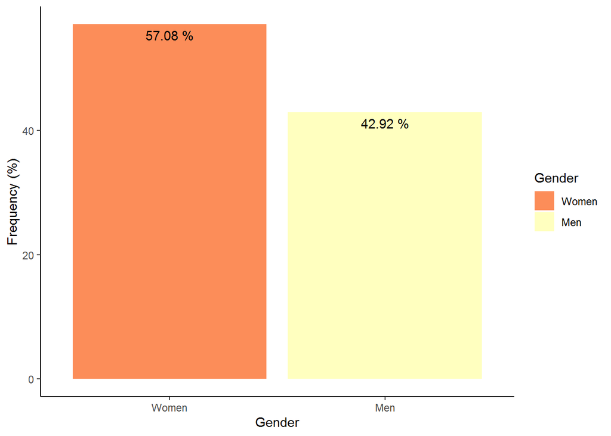

This in terms of analysis of heart disease would tell us that the higher proportion of individuals would have lower risk of heart disease, so according to the Mexican Heart Foundation estrogen which is the female hormone acts as a protective factor against cardiovascular disease, only after menopause in women, their risk of contracting this disease increases considerably.

However, it is important to understand that estrogen generated naturally acts as a protective factor, but the artificial use of estrogen as a treatment in women increases the risk of thrombosis and/or the formation of clots in the arteries.

### Figure 5: Distribution of Smokers by Gender

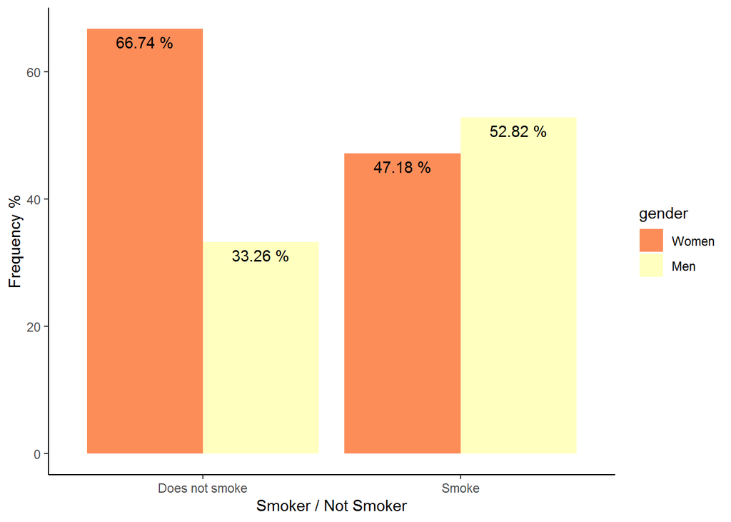

In **Figure 5** we can see that the demographic distribution of smokers shows that 66.74% of non-smokers are women while 52.82% of smokers are men. This implies that people who smoke have a relatively homogeneous distribution by gender, while the majority of non-smokers are women.

### Figure 6: Proportion of people at risk of a heart attack in 10 years given a history of heart disease

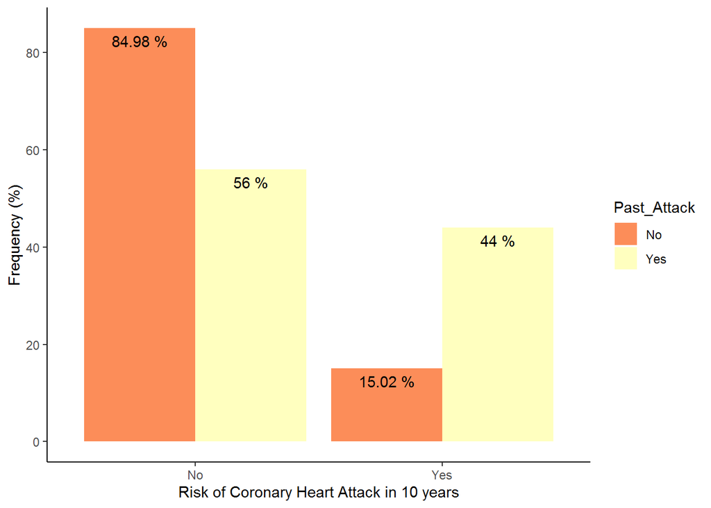

In **Figure 6** we can see that of the people who suffered a heart attack in the past, i.e. who have a history of heart disease 56% have no risk of suffering another attack in 10 years, this may imply some issues such as for example that the history of heart disease is not as relevant a predictor as the other risk factors for acute myocardial attack, or that the previous history encourages the person to periodic risk factor control leading to a reduced risk of heart attack in the future.

### Figure 7: History of Heart Attack given a History of Arterial Hypertension

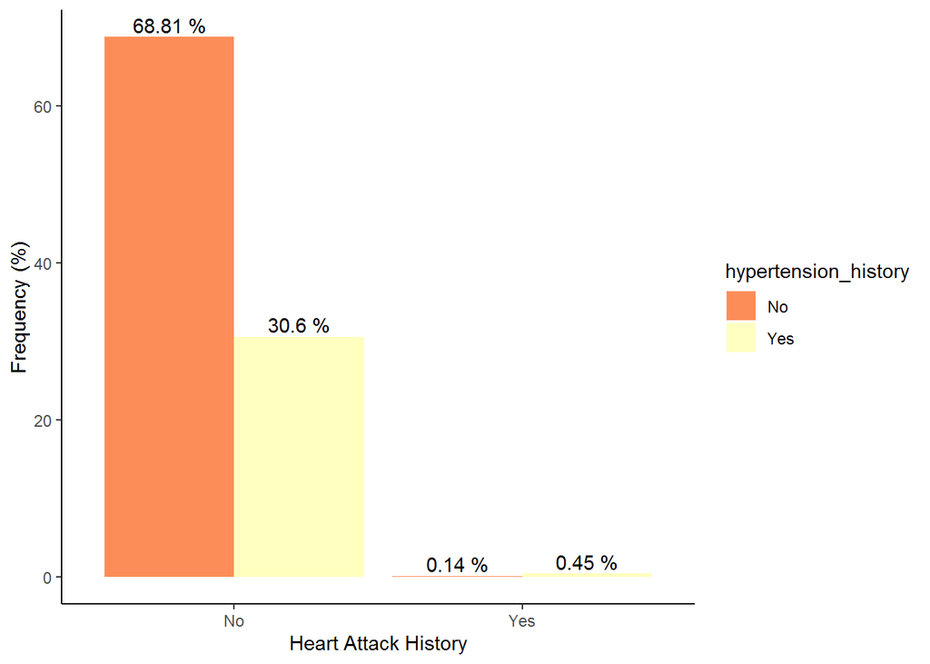

### Figure 8: Proportion of Individuals with Diabetes who are at Risk of Heart Attack

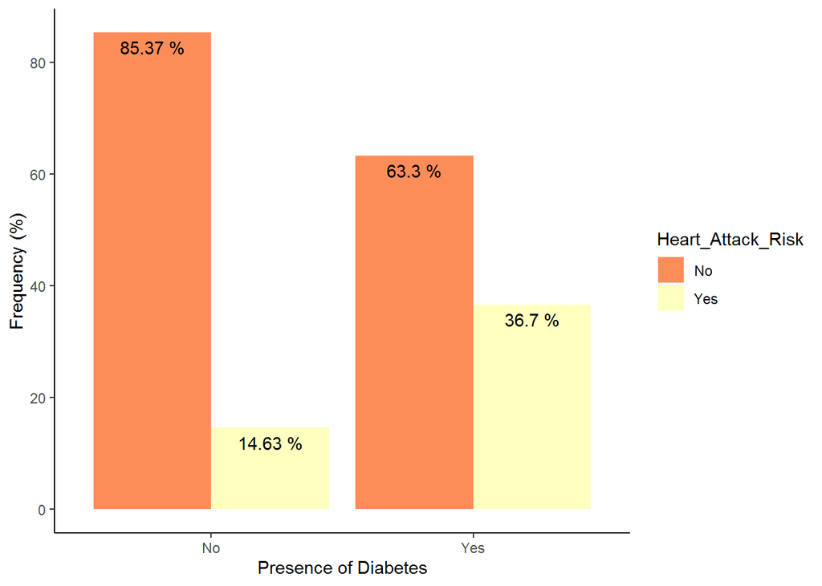

**Figure 8** shows that of those who do not have diabetes, 85.37% have no risk of a heart attack in 10 years, while 63.3% of those who do have diabetes also have no risk of suffering a heart attack in the future. This leads us to think that perhaps diabetes by itself is not a strong risk factor for the prediction of acute myocardial infarction, or that on the other hand the presence of diabetes increases the medical control of other risk factors.

### Figure 9: Distribution of Heart Attack Risk over 10 years

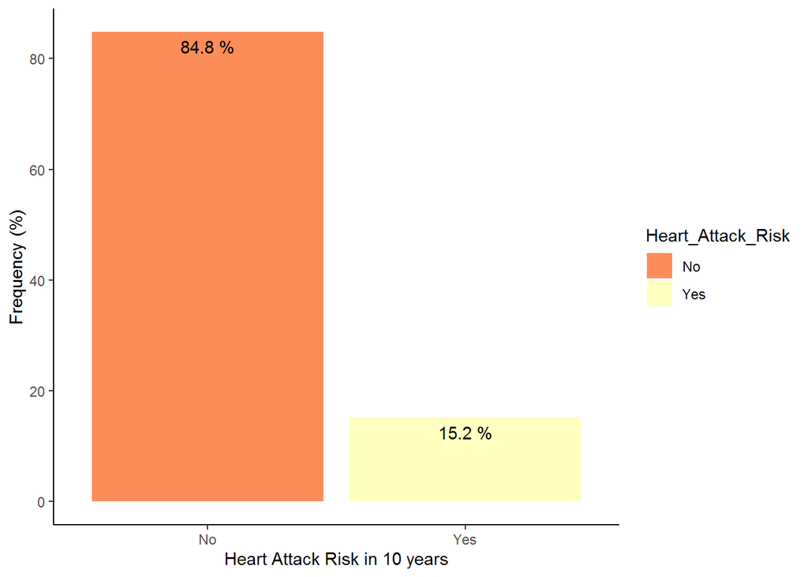

**Figure 9** tells us that the largest proportion of individuals in the sample, that is 84.8% of people, are not at risk of having a heart attack. So if we choose someone at random they are probably not going to be at risk of having a heart attack in 10 years.

Finally, if we want to use this variable as a response, it could be thought that there may be a class imbalance.

### Methodology

The purpose of this work is to use the theory and application of binary response regression models, in this specific case a logistic regression model with Logit link. The purpose of this model is to achieve a good prediction as to whether a person may or may not die of cardiac arrest, as well as to identify the variables that have the greatest impact on this phenomenon. The study group is a community in Framingham, Massachusetts, of at least 4000 observations and 16 variables.

On the other hand, the database had missing data as can be seen in **Table 3**, for which an imputation was performed by the “Random forest” method that “consists of the combination of predictors based on decision or regression trees that are constructed from independent samples selected from the original data set.” *Busi J. et al (2018)* Under the above methodology this method is considered robust when imputing data, both quantitative and qualitative, i.e., for this case study it is a convenient methodology.

### Table 3: Percentage of Missing Values for Quantitative Variables

| Variables | Missing Data (%) |
| --- | --- |
| Age | 0.00 |
| Cigarettes per Day | 0.68 |
| Total Cholesterol | 1.17 |
| Systolic Blood Pressure | 0.00 |
| Diastolic Blood Pressure | 0.00 |
| Body Mass Index | 0.44 |
| Heart Rate | 0.00 |
| Glucose | 9.15 |

### Figure 10: Unbalanced Class Adjustment

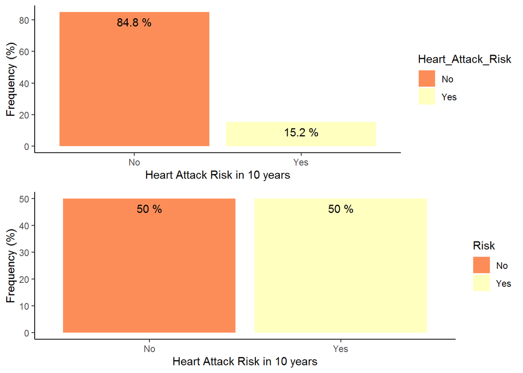

As we can see in **Figure 10** initially for our response variable, which is the 10-year risk of having a heart attack. In our original sample of approximately 4500 observations, we had that 84.8% of people had no 10-year risk of a heart attack while 15.2% did. In that vein, there may be data imbalance that would significantly affect the accuracy of our classifier to correctly detect true positives.

For this reason, we used an oversampling technique to rescale the category of yes in the heart attack risk variable by 10 years. What this does is to take a random sample with replacement and add observations until the number of observations in the “at risk” category is exactly the same as the “not at risk” category. After oversampling we have a total of 7188 observations where 50% are in the risky class and the other 50% are in the non-risky class.

### Table 4: Information Value (IV) for predictor variables

| Variable | IV | Predictive Power |
| --- | --- | --- |
| male | 0.064 | Weak |
| age | 0.000 | Useless |
| currentSmoker | 0.003 | Useless |
| cigsPerDay | 0.000 | Useless |
| BPMeds | 0.072 | Weak |
| prevalentStroke | 0.018 | Weak |
| prevalentHyp | 0.228 | Medium |
| diabetes | 0.069 | Weak |
| totChol | 0.000 | Useless |
| sysBP | 0.000 | Useless |
| diaBP | 0.000 | Useless |
| BMI | 0.000 | Useless |
| heartRate | 0.000 | Useless |
| glucose | 0.000 | Useless |

Information Value is an exploratory analysis technique, which allows us to determine which variables in our data set have predictive power or influence on the response variable, for this reason in **Table 4** we determine the power of influence of each of our explanatory variables, where we find that gender and the presence of diabetes have low predictive power, while the presence of arterial hypertension has medium predictive power; The rest of the variables have a useless predictive power however they are not discarded in their totality for the modeling in order to avoid the loss of information and the omission of statistically significant variables.

### Results

To respond to our main objective, two models were developed. The first is focused on the interpretation of estimators and on answering the hypotheses we posed in the context of the problem, whereas our second model is intended to serve as a classifier of the 10-year risk of heart attack.

### Table 5: Explanatory Model on Logarithmic Scale

```
##
## Call:
## glm(formula = TenYearCHD ~ male + age + prevalentStroke + diabetes +
##     totChol + cigsPerDay + prevalentHyp + sysBP + currentSmoker *
##     male, family = "binomial", data = datos_balanceados)
##
## Deviance Residuals:
##      Min        1Q    Median        3Q       Max
## -2.22442  -1.00865  -0.08788   1.02244   2.12520
##
## Coefficients:
##                        Estimate Std. Error z value Pr(>|z|)
## (Intercept)          -6.2994605  0.2752677 -22.885  < 2e-16 ***
## male1                 0.4820272  0.0771637   6.247 4.19e-10 ***
## age                   0.0636392  0.0034524  18.433  < 2e-16 ***
## prevalentStroke1      0.8505160  0.3179723   2.675  0.00748 **
## diabetes1             0.9802093  0.1465686   6.688 2.27e-11 ***
## totChol               0.0018156  0.0005846   3.106  0.00190 **
## cigsPerDay            0.0162436  0.0035850   4.531 5.87e-06 ***
## prevalentHyp1         0.2080041  0.0734405   2.832  0.00462 **
## sysBP                 0.0147062  0.0016045   9.166  < 2e-16 ***
## currentSmoker1        0.1126806  0.0918505   1.227  0.21990
## male1:currentSmoker1  0.0154383  0.1110000   0.139  0.88938
## ---
## Signif. codes:  0 '***' 0.001 '**' 0.01 '*' 0.05 '.' 0.1 ' ' 1
##
## (Dispersion parameter for binomial family taken to be 1)
##
##     Null deviance: 9964.7  on 7187  degrees of freedom
## Residual deviance: 8705.2  on 7177  degrees of freedom
## AIC: 8727.2
##
## Number of Fisher Scoring iterations: 4
```

### Table 6: Explanatory Model in Real Scale

```
##          (Intercept)                male1                  age
##          0.001837296          1.619353805          1.065707800
##     prevalentStroke1            diabetes1              totChol
##          2.340854434          2.665014021          1.001817238
##           cigsPerDay        prevalentHyp1                sysBP
##          1.016376213          1.231218276          1.014814845
##       currentSmoker1 male1:currentSmoker1
##          1.119274403          1.015558044
```

### Table 7: Performance Metrics of Elastic Net Classificator

```
## Method: maximize_metric
## Predictor: respuesta
## Outcome: TenYearCHD
## Direction: >=
##
##     AUC    n n_pos n_neg
##  0.6568 7188  3594  3594
##
##  optimal_cutpoint sum_sens_spec    acc sensitivity specificity   tp   fn  fp
##                 1        1.3136 0.6568      0.4972      0.8164 1787 1807 660
##    tn
##  2934
##
## Predictor summary:
##     Data Min. 5% 1st Qu. Median      Mean 3rd Qu. 95% Max.        SD NAs
##  Overall    0  0       0      0 0.3404285       1   1    1 0.4738862   0
##        0    0  0       0      0 0.1836394       0   1    1 0.3872437   0
##        1    0  0       0      0 0.4972176       1   1    1 0.5000618   0
```

### Figure 11: ROC curve

[figure not shown]

For the second model we used an approach where we found the model with the lowest akaike information criterion. We took the equation that yielded this result and used regularization methods, specifically the Elastic Net, this model takes a Ridge penalty, i.e. as the lambda value approaches 1 the lower the value of the predictors and the Lasso penalty. This is similar, however it has the effect of forcing the coefficients of the predictors to tend to zero, this allows us to reduce non-significant variables or those that do not provide additional information as well as to solve multicollinearity problems.

For this case, we estimate the optimal value of the lambda regularization hyperparameter. This simply gives a weighting to the stronger penalty if the Ridge or Lasso. So ultimately with regularization we seek to reduce the variance as much as possible in exchange for gaining higher bias.

In this order of ideas, we have that the classifier is good at detecting true negatives, i.e. those persons who do not have cardiovascular risk within the group of those who really do not, and is relatively weak at detecting cardiovascular risk within the group who really have cardiovascular risk in 10 years.

### Bibliography

1. Texas Heart Institute. Cardiovascular Risk Factors. Taken from: https://www.texasheart.org/heart-health/heart-information-center/topics/factores-de-riesgo-cardiovascular/
2. DrC. González R., DrC. Montes L., MSc. Tutusaus T. (2015) Sociodemographic Determinants and Sudden Cardiovascular Death. Cuban Journal of Public Health.
3. Centers for Disease Control and Prevention (2021). About the Body Mass Index for Adults. Taken from: https://www.cdc.gov/healthyweight/spanish/assessing/bmi/adult_bmi/index.html
4. PhD Reiner K. et al (2011). Socioeconomic Status and Incidence of Sudden Cardiac Arrest. Journal of the Canadian Medical Association (15), 1705 - 1712
5. Centers for Disease Control and Prevention (2018). Diabetes in Spanish. Taken from: https://www.cdc.gov/diabetes/spanish/basics/getting-tested.html#:~:text=Los%20valores%20de%20az%C3%BAcar%20en,mayores%20indican%20que%20tiene%20diabetes.&text=Esta%20prueba%20mide%20sus%20niveles,un%20l%C3%ADquido%20que%20contiene%20glucosa.
6. Mexican Heart Foundation . Gender. Taken from: https://fundacionmexicanadelcorazon.org/prevencion/factores-de-riesgo/genero/#:~:text=El%20g%C3%A9nero%20se%20considera%20un,que%20el%20de%20una%20mujer
7. National Health Observatory (2013). Cardiovascular Disease: Leading Cause of Death in Colombia. Bulletin No. 1, december 9 of 2013
8. Bussi J. et al. (2018). Visualization and Imputation Methods for Missing Data in the Household Expenditure Survey.
9. Segura R. , Perez I. (2016). Differential impact of stress between men and women: A gender approach.. FES Iztacala Institutional Gender Studies Program.
10. Mayo Clinic. Healthy Lifestyle: Being fit. Taken from: https://www.mayoclinic.org/es-es/healthy-lifestyle/fitness/expert-answers/heart-rate/faq-20057979